# East Australian Current, SST and the EAC extension

IMAS Honours 2026 — Harry Silke

2026-10-30

## What changed from the previous version

Only the current annotation is rebuilt. The temperature field, the colour scale, the Bass Strait box, the land polygon and every place label are unchanged.

**Line weights now match the physics.** `eac_main` ran bold and solid from 22 °S all the way to 40 °S, while the eastward branch was the thinnest, dotted line. That says most of the flow continues to Tasmania, which is backwards. At separation the bulk of the transport turns east as the Tasman Front; what goes south is the remainder. So `eac_main` now stops at the separation latitude, the eastward branch inherits the bold solid line and the arrowhead, and the southward extension is thin and dashed.

**One southward path, not two.** The original drew a solid arrow ending at 40 °S *and* a dashed arrow curving to 43.5 °S, which read as two different phenomena. Only the extension remains.

**The separation label has something to point at.** It sat at 36.5 °S with nothing happening at the latitude it names. There is now a marker at the branch point and the label sits beside it.

**The extension is drawn as eddies.** It does not travel south as a jet. The open circles along the dashed path say so without a word, and they set up the argument that heat arrives in pulses rather than as steady warming.

## Setup

```r
library(ggplot2)
library(dplyr)
library(sf)
library(rnaturalearth)
library(rnaturalearthdata)
```

```r
# NOAA OISST V2.1, annual mean 2015. Keep the CSV beside this Rmd.
sst_mean <- read.csv("oisst_annual_mean_seaus.csv")

cat("SST grid cells:", nrow(sst_mean), "\n")
```

```
## SST grid cells: 4035
```

```r
cat("SST range:", round(min(sst_mean$sst), 1), "to",
    round(max(sst_mean$sst), 1), "°C\n")
```

```
## SST range: 11.1 to 26.5 °C
```

```r
aus <- ne_countries(country = "Australia", scale = "medium",
                    returnclass = "sf")
```

## Current pathway

```r
SEP_LON <- 153.0
SEP_LAT <- -34.0

# the EAC proper: ends where it leaves the coast
eac_main <- data.frame(
  lon = c(151.0, 153.5, 154.5, 155.0, 154.5, 154.0, SEP_LON),
  lat = c(-22.0, -24.0, -26.0, -28.0, -30.0, -32.0, SEP_LAT)
)

# the Tasman Front: most of the transport, so this keeps the bold line
tasman_front <- data.frame(
  lon = c(SEP_LON, 154.5, 156.0, 157.6),
  lat = c(SEP_LAT, -34.5, -35.0, -35.6)
)

# the extension: the remainder, eddy-driven, reaching Tasmania
eac_extension <- data.frame(
  lon = c(SEP_LON, 152.5, 151.5, 151.0, 150.5, 149.5, 149.0),
  lat = c(SEP_LAT, -36.0, -38.0, -40.0, -41.0, -42.0, -43.5)
)

# a few eddies along it, so it does not read as a jet
eddies <- eac_extension[c(2, 3, 4, 6), ]
eddies$r <- c(2.6, 2.4, 2.2, 2.0)
```

## Figure A

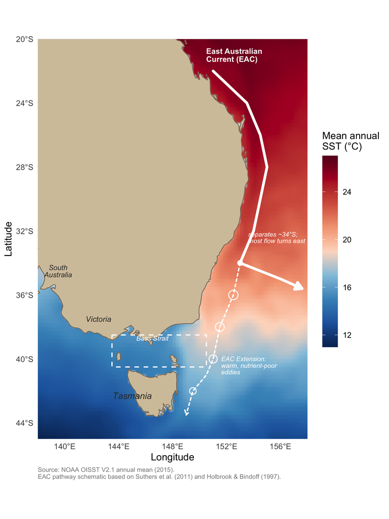

**Figure 3.** Annual mean sea surface temperature along the east Australian coast (NOAA OISST V2.1, 2015). The East Australian Current runs south along the coast and separates near 34 degrees south, where most of its transport turns east as the Tasman Front. The remainder continues south as the EAC extension, a train of warm, nutrient-poor eddies reaching Tasmania. EAC pathway schematic based on Suthers et al. (2011) and Holbrook & Bindoff (1997).

```r
p_sst <- ggplot() +
  geom_raster(data = sst_mean, aes(x = lon, y = lat, fill = sst),
              interpolate = TRUE) +
  scale_fill_gradientn(
    colours  = c("#053061", "#2166ac", "#4393c3", "#92c5de",
                 "#fddbc7", "#f4a582", "#d6604d", "#b2182b", "#67001f"),
    name     = "Mean annual\nSST (°C)",
    na.value = "white", limits = c(11, 27), breaks = seq(12, 26, 4)
  ) +
  geom_sf(data = aus, fill = "#d4c5a9", colour = "#8a7560",
          linewidth = 0.4) +

  # the current, bold to the separation point, no arrowhead yet
  geom_path(data = eac_main, aes(lon, lat), colour = "white",
            linewidth = 1.4, lineend = "round", linejoin = "round") +

  # the Tasman Front keeps the bold line and takes the arrowhead
  geom_path(data = tasman_front, aes(lon, lat), colour = "white",
            linewidth = 1.4, lineend = "round", linejoin = "round",
            arrow = arrow(length = unit(0.3, "cm"), type = "closed")) +

  # the extension, thin and dashed, with an open arrowhead
  geom_path(data = eac_extension, aes(lon, lat), colour = "white",
            linewidth = 0.7, linetype = "22", lineend = "round",
            arrow = arrow(length = unit(0.2, "cm"), type = "open")) +
  geom_point(data = eddies, aes(lon, lat, size = r), shape = 21,
             colour = "white", fill = NA, stroke = 0.7,
             show.legend = FALSE) +
  scale_size_continuous(range = c(3.0, 4.4)) +

  # the separation now has a marker under its label
  geom_point(aes(x = SEP_LON, y = SEP_LAT), shape = 21, size = 2.2,
             colour = "white", fill = "white", stroke = 0.6) +

  # Bass Strait box, unchanged
  annotate("rect", xmin = 143.5, xmax = 150.5, ymin = -40.5, ymax = -38.5,
           fill = NA, colour = "white", linewidth = 0.6,
           linetype = "dashed") +
  annotate("text", x = 146.5, y = -38.7, label = "Bass Strait",
           colour = "white", size = 2.6, fontface = "italic") +

  annotate("text", x = 150.5, y = -21, label = "East Australian\nCurrent (EAC)",
           colour = "white", size = 3.0, fontface = "bold",
           lineheight = 0.85, hjust = 0) +
  annotate("text", x = 153.6, y = -32.4,
           label = "separates ~34°S;\nmost flow turns east",
           colour = "white", size = 2.5, fontface = "italic",
           lineheight = 0.85, hjust = 0) +
  annotate("text", x = 151.6, y = -40.4,
           label = "EAC Extension:\nwarm, nutrient-poor\neddies",
           colour = "white", size = 2.5, fontface = "italic",
           lineheight = 0.85, hjust = 0) +
  annotate("text", x = 145.0, y = -42.3, label = "Tasmania",
           colour = "grey20", size = 3.5, fontface = "italic") +
  annotate("text", x = 142.5, y = -37.5, label = "Victoria",
           colour = "grey20", size = 3.0, fontface = "italic") +
  annotate("text", x = 139.5, y = -34.5, label = "South\nAustralia",
           colour = "grey20", size = 2.8, fontface = "italic",
           lineheight = 0.85) +

  coord_sf(xlim = c(138, 158), ylim = c(-45, -20), expand = FALSE) +
  scale_x_continuous(breaks = seq(140, 158, 4),
                     labels = function(x) paste0(x, "°E"),
                     name = "Longitude") +
  scale_y_continuous(breaks = seq(-44, -20, 4),
                     labels = function(y) paste0(abs(y), "°S"),
                     name = "Latitude") +
  labs(caption = paste0("Source: NOAA OISST V2.1 annual mean (2015).\n",
                        "EAC pathway schematic based on Suthers et al. (2011) ",
                        "and Holbrook & Bindoff (1997).")) +
  theme_minimal(base_size = 11) +
  theme(
    plot.caption      = element_text(size = 7, colour = "#888888", hjust = 0),
    panel.background  = element_rect(fill = "#cde8f0", colour = NA),
    panel.grid        = element_line(colour = "#b0cfd8", linewidth = 0.2),
    plot.background   = element_rect(fill = "white", colour = NA),
    legend.position   = "right",
    legend.key.height = unit(1.5, "cm"),
    plot.margin       = margin(5, 5, 5, 5)
  )

p_sst
```

```r
ggsave("kelp_EAC_SST_map.png", p_sst, width = 6, height = 8,
       dpi = 300, bg = "white")
```